# Activity Monitoring Analysis

Daniel Smit

2022-06-19

## Loading and preprocessing the data

We load the data from a CSV.

```r
activity = read.csv('activity.csv');

summary(activity)
```

```
##      steps            date              interval
##  Min.   :  0.00   Length:17568       Min.   :   0.0
##  1st Qu.:  0.00   Class :character   1st Qu.: 588.8
##  Median :  0.00   Mode  :character   Median :1177.5
##  Mean   : 37.38                      Mean   :1177.5
##  3rd Qu.: 12.00                      3rd Qu.:1766.2
##  Max.   :806.00                      Max.   :2355.0
##  NA's   :2304
```

Notice a number of NA step values. Until we start estimating the NA values, we will exclude results with NA values.

```r
activityNoNA = na.omit(activity)
```

## What is mean total number of steps taken per day?

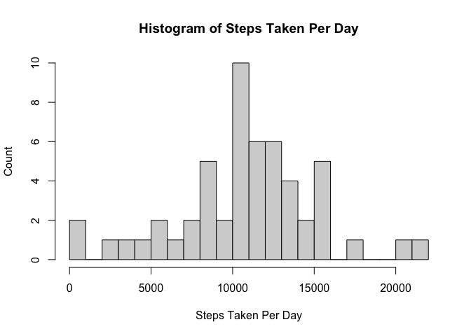

```r
stepsPerDay = aggregate(steps ~ date, activityNoNA, sum)

hist(x=stepsPerDay$steps, breaks=30,
     main='Histogram of Steps Taken Per Day',
     xlab='Steps Taken Per Day',
     ylab='Count')
```

We calculate the mean and median as follows.

```r
meanSteps = mean(stepsPerDay$steps)
medianSteps = median(stepsPerDay$steps)

cat('Mean steps: ', meanSteps, '\n')
```

```
## Mean steps:  10766.19
```

```r
cat('Median steps: ', medianSteps)
```

```
## Median steps:  10765
```

## What is the average daily activity pattern?

First we determine the mean steps for each 5 minute interval, then display on a time series plot.

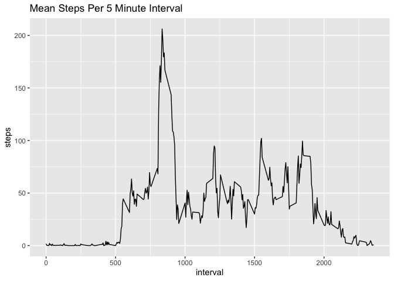

```r
meanStepsByInterval = aggregate(steps ~ interval, activityNoNA, mean)

library(ggplot2)
ggplot(meanStepsByInterval, aes(x=interval, y=steps)) + geom_line() +
  ggtitle("Mean Steps Per 5 Minute Interval")
```

What interval contains the max number of steps on average?

```r
rowWithMaxMeanSteps = meanStepsByInterval[which.max(meanStepsByInterval$steps),]

cat('Max mean steps during interval ', rowWithMaxMeanSteps$interval, ' with ', rowWithMaxMeanSteps$steps, ' steps.')
```

```
## Max mean steps during interval  835  with  206.1698  steps.
```

## Inputting missing values

How many rows contain NAs?

```r
numRowsWithNAs = sum(!complete.cases(activity))

cat(numRowsWithNAs, ' rows with NAs')
```

```
## 2304  rows with NAs
```

Let’s bring the number of NA step values to zero through estimation, by using the mean steps for that time interval across the entire series.

For this, let’s continue using the `meanStepsByInterval` as calculated earlier.

```r
intervalValues <- unique(activity$interval)

filledActivity = activity
stepsCol <- 1
intervalCol <- 3

for(row in 1:nrow(filledActivity)){
  if(is.na(filledActivity[row,stepsCol])) {
    intervalIndex <- match(filledActivity[row,intervalCol], intervalValues)
    filledActivity[row,stepsCol] <- meanStepsByInterval[intervalIndex, 2]
  }
}

summary(filledActivity)
```

```
##      steps            date              interval
##  Min.   :  0.00   Length:17568       Min.   :   0.0
##  1st Qu.:  0.00   Class :character   1st Qu.: 588.8
##  Median :  0.00   Mode  :character   Median :1177.5
##  Mean   : 37.38                      Mean   :1177.5
##  3rd Qu.: 27.00                      3rd Qu.:1766.2
##  Max.   :806.00                      Max.   :2355.0
```

Let’s plot a histogram of this estimated data.

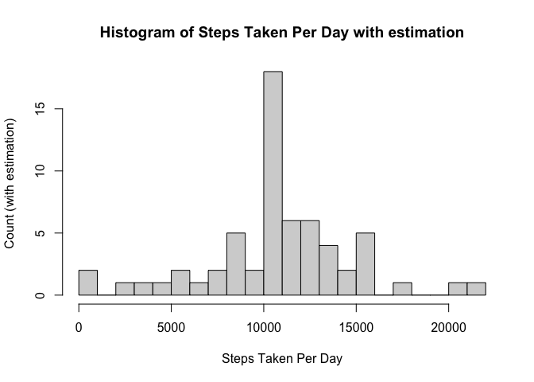

```r
stepsPerDayEstimated = aggregate(steps ~ date, filledActivity, sum)

hist(x=stepsPerDayEstimated$steps, breaks=30,
     main='Histogram of Steps Taken Per Day with estimation',
     xlab='Steps Taken Per Day',
     ylab='Count (with estimation)')
```

Let’s calculate the mean and median.

```r
filledMeanSteps = mean(stepsPerDayEstimated$steps)
filledMedianSteps = median(stepsPerDayEstimated$steps)

cat('Filled mean steps: ', filledMeanSteps, '\n')
```

```
## Filled mean steps:  10766.19
```

```r
cat('Filled median steps: ', filledMedianSteps)
```

```
## Filled median steps:  10766.19
```

Just to remind you once again, the original mean and medians, before filling in NA step values, were:

```r
cat('Mean steps: ', meanSteps, '\n')
```

```
## Mean steps:  10766.19
```

```r
cat('Median steps: ', medianSteps)
```

```
## Median steps:  10765
```

The means are the same before and after filling in missing data, but the median has changed slightly.

## Are there differences in activity patterns between weekdays and week-ends?

Let’s go back to the original data set and add a column specifying whether the row was taken on a weekend or not.

```r
library(chron)
library(dplyr)
activityWithWeekendCol = mutate(activity, isWeekend = is.weekend(date))
```

Now let’s plot the time series plots for weekdays and weekends.

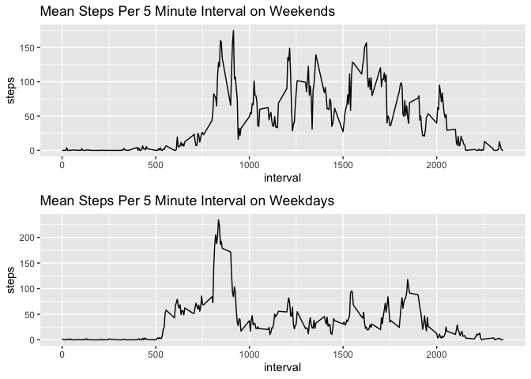

```r
weekdayActivity = activityWithWeekendCol[!activityWithWeekendCol$isWeekend,]
weekendActivity = activityWithWeekendCol[activityWithWeekendCol$isWeekend,]

meanStepsByIntervalOnWeekdays = aggregate(steps ~ interval, weekdayActivity, mean)
meanStepsByIntervalOnWeekends = aggregate(steps ~ interval, weekendActivity, mean)

weekdaysPlot <- ggplot(meanStepsByIntervalOnWeekdays, aes(x=interval, y=steps)) + geom_line() +
  ggtitle("Mean Steps Per 5 Minute Interval on Weekdays")

weekendsPlot <- ggplot(meanStepsByIntervalOnWeekends, aes(x=interval, y=steps)) + geom_line() +
  ggtitle("Mean Steps Per 5 Minute Interval on Weekends")

require(gridExtra)
grid.arrange(weekendsPlot, weekdaysPlot, nrow=2)
```

We notice a fairly significant difference between the weekends and weekday means. On weekdays, there was less activity from interval 1000 onwards than on weekends. Both plots do however show a lack of activity during late night/early morning hours, and a stretch of increased activity just prior to interval 1000.